# INTRO TO TIDYVERSE: TYPES OF VISUALIZATION

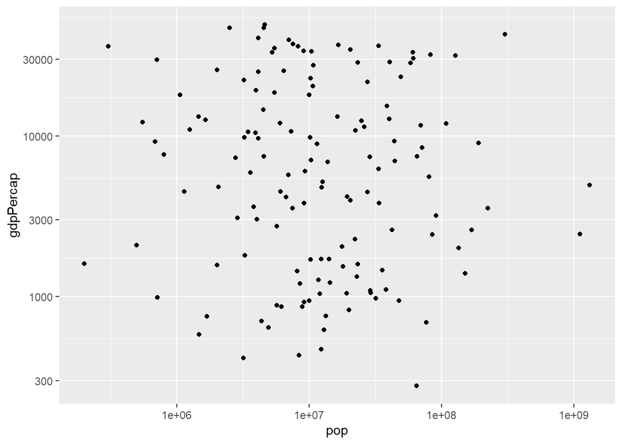

```r
ggplot(gapminder_2007,
       aes(pop, gdpPercap)) +
  geom_point() +
  scale_x_log10() +
  scale_y_log10()
```

Choose a variable to represent with color:

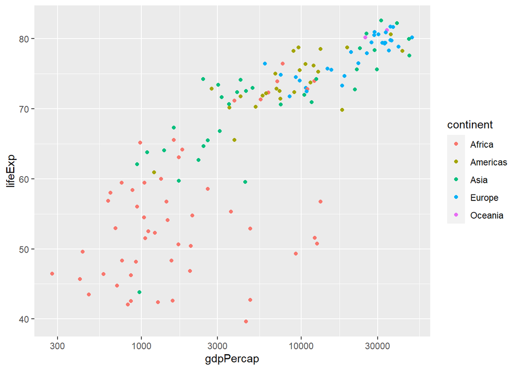

```r
ggplot(gapminder_2007,
       aes(gdpPercap, lifeExp,
           color = continent)) +
  geom_point() +
  scale_x_log10()     # ggplot2 automatically adds a legend.
```

Another aesthetic is size which is great for representing numeric variables:

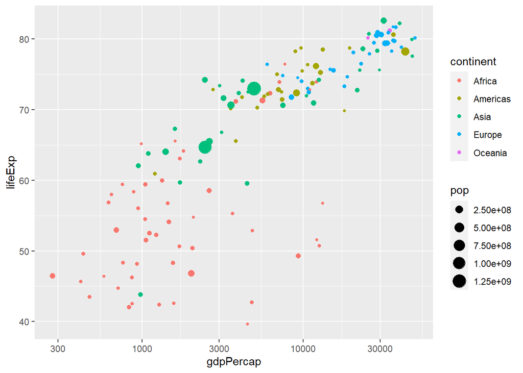

```r
ggplot(gapminder_2007,
       aes(gdpPercap, lifeExp,
           color = continent,
           size = pop)) +
  geom_point() +
  scale_x_log10()
```

ggplot2 supports *faceting*: dividing the graph into one small sub-graph for each continent.

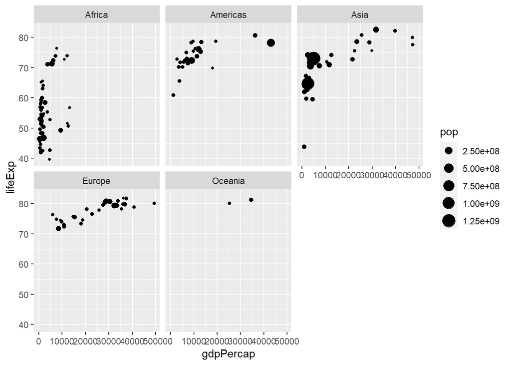

```r
ggplot(gapminder_2007,
       aes(gdpPercap, lifeExp,
           size = pop)) +
  geom_point() +
  facet_wrap(~ continent)
```

Graph the full Gapminder data and facet on year, which lists the graph communicate changes over time:

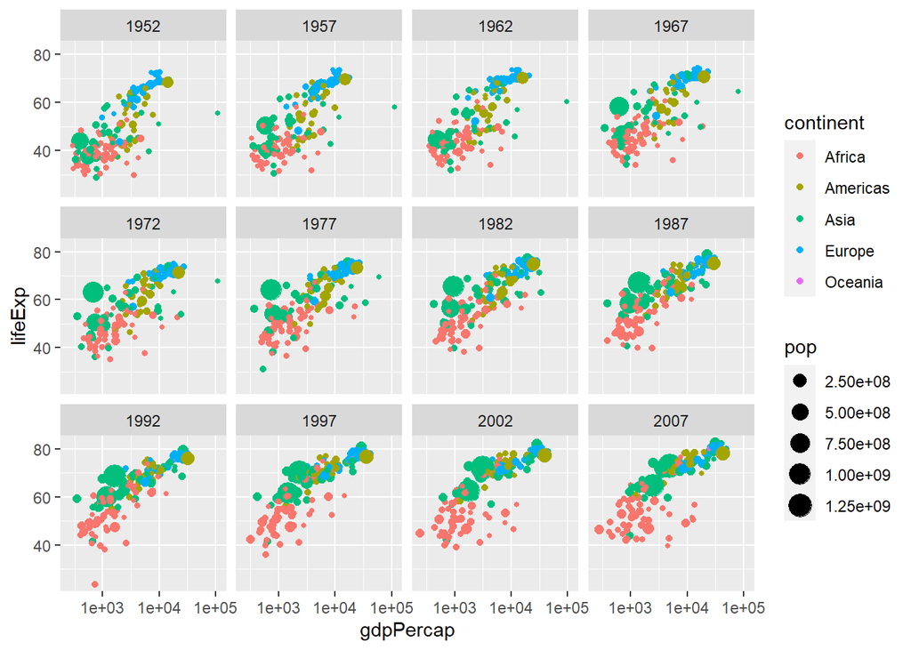

```r
ggplot(gapminder,
       aes(gdpPercap, lifeExp,
           color = continent,
           size = pop)) +
  geom_point() +
  scale_x_log10() +
  facet_wrap(~year)   # people has lived longer since 1952.
```

### 3. Types of visualization

- Line plots:

Geometric layer for line plots: `geom_line`

```r
by_year <- gapminder %>%
  group_by(year) %>%
  summarize(totalPop = sum(pop),
            meanLifeExp = mean(lifeExp))
```

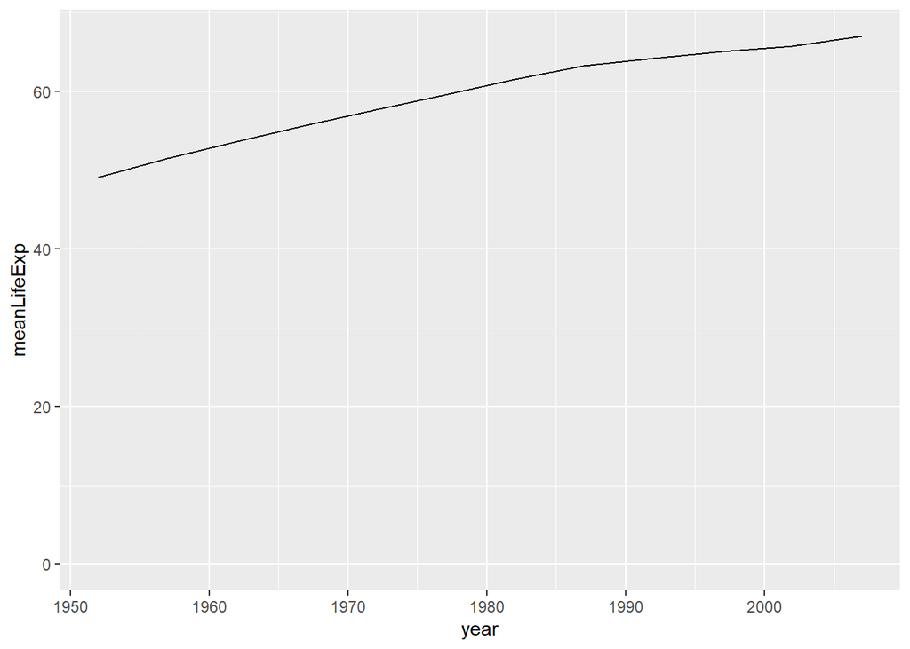

```r
ggplot(by_year,
       aes(year,  meanLifeExp)) +
  geom_line() +           # to use lines for graph
  expand_limits(y = 0)
```

Summarize by two variables:

```r
year_continent <- gapminder %>%
  group_by(year, continent) %>%
  summarize(totalPop = sum(pop),
            medianLifeExp = median(lifeExp))
```

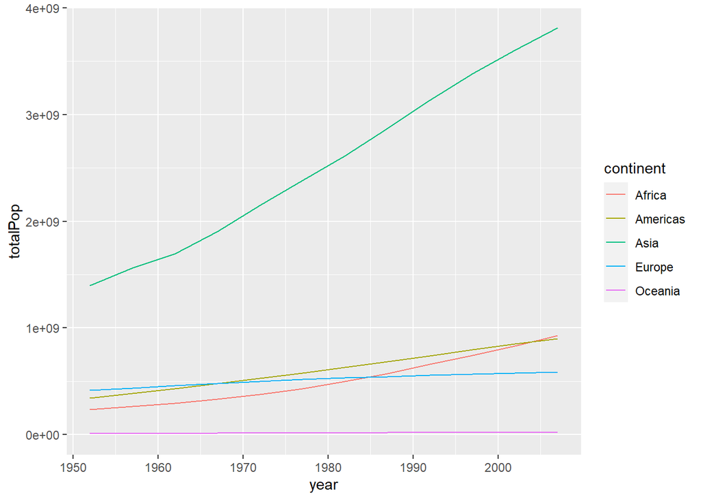

```r
ggplot(year_continent,
       aes(year, totalPop,
           color = continent)) +
  geom_line() +
  expand_limits(y = 0)
```

- Bar plots:

Create bar plots with `geom_col()`:

```r
by_continent <- gapminder %>%
  filter(year == 2007) %>%
  group_by(continent) %>%
  summarize(totalPop = sum(pop),
            meanLifeExp = mean(lifeExp))
```